# NetCOLOR project

Last compiled on 22 March, 2021

This section shows some graphics about the processed data. The data consists in three `.csv` files:

1. `metadata.csv`
2. `hplc.csv`
3. `absorption.csv`

`sample_id` *438116* was duplicated and removed from the data.

## Mismatch between metadata, HPLC and absorption

The following table shows the HPLC data that have no metadata associated.

| sample_id | depth | chlb | chlc12 | chlc3 | chlidea | hplchla | totchlc | hplcchlc | hplcchla | but19 | hex19 | allox | acarot | astax | bcarot | butlike | diadinox | diatox | fucox | hexlike2 | hexlike | hplcphae | perid | prasinox | pyrophae | violax | zea | abs_vol_l |
| --- | --- | --- | --- | --- | --- | --- | --- | --- | --- | --- | --- | --- | --- | --- | --- | --- | --- | --- | --- | --- | --- | --- | --- | --- | --- | --- | --- | --- |
| 476251 | 4 | 0.19337546 | 0.000000000 | 0.00000000 | 0.000000000 | 0.42530614 | 0.000000000 | NA | NA | 0.000000000 | 0.000000000 | 0.000000000 | 0.000000000 | 0.00000000 | 0.000000000 | 0 | 0.000000000 | 0.000000000 | 0.00000000 | 0 | 0 | 0.00000000 | 0.000000000 | 0.00000000 | 0.00000000 | 0.00000000 | 0.000000000 | 0.70 |
| 476252 | 4 | 0.16398187 | 0.000000000 | 0.00000000 | 0.000000000 | 0.54147226 | 0.000000000 | NA | NA | 0.000000000 | 0.000000000 | 0.000000000 | 0.000000000 | 0.00000000 | 0.000000000 | 0 | 0.000000000 | 0.000000000 | 0.00000000 | 0 | 0 | 0.00000000 | 0.000000000 | 0.00000000 | 0.00000000 | 0.00000000 | 0.000000000 | 0.25 |
| 476253 | 4 | 0.00000000 | 0.442949270 | 0.00000000 | 0.000000000 | 3.63602321 | 0.442949270 | NA | NA | 0.000000000 | 0.000000000 | 0.000000000 | 0.000000000 | 0.00000000 | 0.000000000 | 0 | 0.173217638 | 0.000000000 | 1.14245307 | 0 | 0 | 0.00000000 | 0.000000000 | 0.00000000 | 0.00000000 | 0.00000000 | 0.000000000 | 0.25 |
| 476254 | 4 | 0.00000000 | 0.000000000 | 0.00000000 | 0.000000000 | 0.55199514 | 0.000000000 | NA | NA | 0.000000000 | 0.000000000 | 0.000000000 | 0.000000000 | 0.00000000 | 0.000000000 | 0 | 0.037422293 | 0.000000000 | 0.13455865 | 0 | 0 | 0.00000000 | 0.000000000 | 0.00000000 | 0.00000000 | 0.00000000 | 0.000000000 | 0.50 |
| 476255 | 4 | 0.19505376 | 0.557562643 | 0.28029007 | 0.477798173 | 5.24951382 | 0.837852710 | NA | NA | 0.000000000 | 0.212554022 | 0.000000000 | 0.000000000 | 0.00000000 | 0.114385075 | 0 | 0.555547114 | 0.000000000 | 1.90828262 | 0 | 0 | 0.00000000 | 0.000000000 | 0.00000000 | 0.00000000 | 0.00000000 | 0.000000000 | 0.25 |
| 476256 | 4 | 0.00000000 | 0.208394544 | 0.15667442 | 0.000000000 | 1.50143735 | 0.365068963 | NA | NA | 0.000000000 | 0.431032550 | 0.000000000 | 0.000000000 | 0.00000000 | 0.000000000 | 0 | 0.171893318 | 0.000000000 | 0.40089458 | 0 | 0 | 0.00000000 | 0.000000000 | 0.00000000 | 0.00000000 | 0.00000000 | 0.000000000 | 0.25 |
| 476257 | 4 | 0.00000000 | 0.120766464 | 0.09984275 | 0.000000000 | 1.02434386 | 0.220609210 | NA | NA | 0.000000000 | 0.195677726 | 0.000000000 | 0.000000000 | 0.00000000 | 0.000000000 | 0 | 0.062711678 | 0.000000000 | 0.22721462 | 0 | 0 | 0.00000000 | 0.000000000 | 0.00000000 | 0.00000000 | 0.00000000 | 0.000000000 | 0.50 |
| 476258 | 4 | 0.00000000 | 0.000000000 | 0.00000000 | 0.000000000 | 0.29414568 | 0.000000000 | NA | NA | 0.000000000 | 0.000000000 | 0.000000000 | 0.000000000 | 0.00000000 | 0.000000000 | 0 | 0.000000000 | 0.000000000 | 0.05073901 | 0 | 0 | 0.00000000 | 0.000000000 | 0.00000000 | 0.00000000 | 0.00000000 | 0.000000000 | 0.50 |
| 476259 | 4 | 0.19487328 | 0.086767766 | 0.04853160 | 0.000000000 | 0.94376743 | 0.135299366 | NA | NA | 0.000000000 | 0.079177723 | 0.000000000 | 0.000000000 | 0.00000000 | 0.000000000 | 0 | 0.045182808 | 0.000000000 | 0.11517120 | 0 | 0 | 0.00000000 | 0.000000000 | 0.00000000 | 0.00000000 | 0.00000000 | 0.000000000 | 0.50 |
| 476260 | 4 | 0.00000000 | 0.085695355 | 0.00000000 | 0.000000000 | 0.75519506 | 0.085695355 | NA | NA | 0.000000000 | 0.000000000 | 0.000000000 | 0.000000000 | 0.00000000 | 0.000000000 | 0 | 0.078935026 | 0.000000000 | 0.19777841 | 0 | 0 | 0.43187760 | 0.000000000 | 0.00000000 | 0.00000000 | 0.00000000 | 0.000000000 | 0.50 |

[output cut: 431 more lines]

Now, this table shows the metadata that have no HPLC values associated.

| sample_id | date | cruise_name | cruise_number | longitude | latitude | country_institute_code | organization | chief_scientist | start_date | end_date | platform | cruise_description | pi |
| --- | --- | --- | --- | --- | --- | --- | --- | --- | --- | --- | --- | --- | --- |
| 476334 | 2019-06-10 | LABRADOR SEA | AMU2019001 | -55.55280 | 53.67750 | 1810 | DFO BIO | IGOR YASHAYAEV | 2019-05-30 04:00:00 | 2019-06-23 04:00:00 | AMUNDSEN | ATLANTIC ZONE OFF-SHELF MONITORING PROGRAM (AZOMP) | Emmanuel Devred |
| 476389 | 2019-06-10 | LABRADOR SEA | AMU2019001 | -55.02420 | 54.21920 | 1810 | DFO BIO | IGOR YASHAYAEV | 2019-05-30 04:00:00 | 2019-06-23 04:00:00 | AMUNDSEN | ATLANTIC ZONE OFF-SHELF MONITORING PROGRAM (AZOMP) | Emmanuel Devred |
| 476562 | 2019-06-12 | LABRADOR SEA | AMU2019001 | -52.39130 | 56.81420 | 1810 | DFO BIO | IGOR YASHAYAEV | 2019-05-30 04:00:00 | 2019-06-23 04:00:00 | AMUNDSEN | ATLANTIC ZONE OFF-SHELF MONITORING PROGRAM (AZOMP) | Emmanuel Devred |
| 476923 | 2019-06-16 | LABRADOR SEA | AMU2019001 | -48.36450 | 60.44770 | 1810 | DFO BIO | IGOR YASHAYAEV | 2019-05-30 04:00:00 | 2019-06-23 04:00:00 | AMUNDSEN | ATLANTIC ZONE OFF-SHELF MONITORING PROGRAM (AZOMP) | Emmanuel Devred |
| 477226 | 2019-06-19 | LABRADOR SEA | AMU2019001 | -53.24400 | 58.50670 | 1810 | DFO BIO | IGOR YASHAYAEV | 2019-05-30 04:00:00 | 2019-06-23 04:00:00 | AMUNDSEN | ATLANTIC ZONE OFF-SHELF MONITORING PROGRAM (AZOMP) | Emmanuel Devred |
| 477372 | 2019-06-20 | LABRADOR SEA | AMU2019001 | -53.82720 | 55.41800 | 1810 | DFO BIO | IGOR YASHAYAEV | 2019-05-30 04:00:00 | 2019-06-23 04:00:00 | AMUNDSEN | ATLANTIC ZONE OFF-SHELF MONITORING PROGRAM (AZOMP) | Emmanuel Devred |
| 439053 | 2016-10-01 | SCOTIAN SHELF | HUD2016027 | -66.04530 | 42.11880 | 1810 | DFO BIO | ANDREW COGSWELL | 2016-09-15 04:00:00 | 2016-10-06 04:00:00 | HUDSON | ATLANTIC ZONE MONITORING PROGRAM (AZMP) | Emmanuel Devred |
| 439137 | 2016-10-01 | SCOTIAN SHELF | HUD2016027 | -65.50950 | 42.00250 | 1810 | DFO BIO | ANDREW COGSWELL | 2016-09-15 04:00:00 | 2016-10-06 04:00:00 | HUDSON | ATLANTIC ZONE MONITORING PROGRAM (AZMP) | Emmanuel Devred |
| 449773 | 2018-09-30 | SCOTIAN SHELF | HUD2018030 | -60.21670 | 46.95820 | 1810 | DFO BIO | DAVE HEBERT | 2018-09-15 04:00:00 | 2018-10-07 04:00:00 | HUDSON | ATLANTIC ZONE MONITORING PROGRAM (AZMP) | Emmanuel Devred |
| 450268 | 2018-10-03 | SCOTIAN SHELF | HUD2018030 | -55.83980 | 44.23980 | 1810 | DFO BIO | DAVE HEBERT | 2018-09-15 04:00:00 | 2018-10-07 04:00:00 | HUDSON | ATLANTIC ZONE MONITORING PROGRAM (AZMP) | Emmanuel Devred |

[output cut: 64 more lines]

These are the absorption spectra with no HPLC association.

| sample_id | date | depth | pressure | wavelength | ap | aphy | anap | abs_vol_l | event_number | qc_flag_410_smaller_than_440 | qc_flag_443_to_490 | qc_flag_chl_a_to_443_550_670 | comments | n |
| --- | --- | --- | --- | --- | --- | --- | --- | --- | --- | --- | --- | --- | --- | --- |
| 476334 | 2019-06-10 | NA | 60.312 | 350 | NA | NA | NA | NA | 15 | 0 | 0 | 0 | The Sample ID is missing from HPLC | 1 |
| 476389 | 2019-06-10 | NA | 59.942 | 350 | NA | NA | NA | NA | 27 | 0 | 0 | 0 | The Sample ID is missing from HPLC | 1 |
| 476562 | 2019-06-12 | NA | 30.800 | 350 | NA | NA | NA | NA | 99 | 0 | 0 | 0 | The Sample ID is missing from HPLC | 1 |
| 476923 | 2019-06-16 | NA | 3.458 | 350 | NA | NA | NA | NA | 202 | 0 | 0 | 0 | The Sample ID is missing from HPLC | 1 |
| 477226 | 2019-06-19 | NA | 19.891 | 350 | NA | NA | NA | NA | 290 | 0 | 0 | 0 | The Sample ID is missing from HPLC | 1 |
| 477372 | 2019-06-20 | NA | 3.581 | 350 | NA | NA | NA | NA | 323 | 0 | 0 | 0 | The Sample ID is missing from HPLC | 1 |
| 439053 | 2016-10-01 | NA | 3.174 | 350 | NA | NA | NA | NA | 201 | 0 | 0 | 0 | The Sample ID is missing from HPLC | 1 |
| 439137 | 2016-10-01 | NA | 3.313 | 350 | NA | NA | NA | NA | 212 | 0 | 0 | 0 | The Sample ID is missing from HPLC | 1 |
| 449773 | 2018-09-30 | NA | 30.165 | 350 | NA | NA | NA | NA | 205 | 0 | 0 | 0 | The Sample ID is missing from HPLC | 1 |
| 450268 | 2018-10-03 | NA | 20.542 | 350 | NA | NA | NA | NA | 243 | 0 | 0 | 0 | The Sample ID is missing from HPLC | 1 |

[output cut: 64 more lines]

## Missing geographical coordinates

These are measurements without goegraphical coordinates.

| sample_id | date | cruise_name | cruise_number | longitude | latitude | country_institute_code | organization | chief_scientist | start_date | end_date | platform | cruise_description | pi |
| --- | --- | --- | --- | --- | --- | --- | --- | --- | --- | --- | --- | --- | --- |
| 477269 |  | LABRADOR SEA | AMU2019001 | NA | NA | 1810 | DFO BIO | IGOR YASHAYAEV | 2019-05-30 04:00:00 | 2019-06-23 04:00:00 | AMUNDSEN | ATLANTIC ZONE OFF-SHELF MONITORING PROGRAM (AZOMP) | Emmanuel Devred |
| 477270 |  | LABRADOR SEA | AMU2019001 | NA | NA | 1810 | DFO BIO | IGOR YASHAYAEV | 2019-05-30 04:00:00 | 2019-06-23 04:00:00 | AMUNDSEN | ATLANTIC ZONE OFF-SHELF MONITORING PROGRAM (AZOMP) | Emmanuel Devred |
| 477271 |  | LABRADOR SEA | AMU2019001 | NA | NA | 1810 | DFO BIO | IGOR YASHAYAEV | 2019-05-30 04:00:00 | 2019-06-23 04:00:00 | AMUNDSEN | ATLANTIC ZONE OFF-SHELF MONITORING PROGRAM (AZOMP) | Emmanuel Devred |
| 313555 |  | SCOTIAN SHELF SABLE GULLY | HUD2007033 | NA | NA | 1810 | DFO BIO | BLAIR GREENAN | 2007-08-02 04:00:00 | 2007-08-09 04:00:00 | HUDSON | HYDROGRAPHIC BIOLOGICAL SURVEY | Emmanuel Devred |
| 313600 |  | SCOTIAN SHELF SABLE GULLY | HUD2007033 | NA | NA | 1810 | DFO BIO | BLAIR GREENAN | 2007-08-02 04:00:00 | 2007-08-09 04:00:00 | HUDSON | HYDROGRAPHIC BIOLOGICAL SURVEY | Emmanuel Devred |
| 314021 |  | SCOTIAN SHELF SABLE GULLY | HUD2007033 | NA | NA | 1810 | DFO BIO | BLAIR GREENAN | 2007-08-02 04:00:00 | 2007-08-09 04:00:00 | HUDSON | HYDROGRAPHIC BIOLOGICAL SURVEY | Emmanuel Devred |
| 314022 |  | SCOTIAN SHELF SABLE GULLY | HUD2007033 | NA | NA | 1810 | DFO BIO | BLAIR GREENAN | 2007-08-02 04:00:00 | 2007-08-09 04:00:00 | HUDSON | HYDROGRAPHIC BIOLOGICAL SURVEY | Emmanuel Devred |
| 322021 |  | LABRADOR SEA ~ SCOTIAN SHELF | HUD2008009 | NA | NA | 1810 | DFO BIO | GLEN HARRISON | 2008-05-20 04:00:00 | 2008-06-04 04:00:00 | HUDSON | ATLANTIC ZONE OFF-SHELF MONITORING PROGRAM (AZOMP) | Emmanuel Devred |
| 322054 |  | LABRADOR SEA ~ SCOTIAN SHELF | HUD2008009 | NA | NA | 1810 | DFO BIO | GLEN HARRISON | 2008-05-20 04:00:00 | 2008-06-04 04:00:00 | HUDSON | ATLANTIC ZONE OFF-SHELF MONITORING PROGRAM (AZOMP) | Emmanuel Devred |
| 322092 |  | LABRADOR SEA ~ SCOTIAN SHELF | HUD2008009 | NA | NA | 1810 | DFO BIO | GLEN HARRISON | 2008-05-20 04:00:00 | 2008-06-04 04:00:00 | HUDSON | ATLANTIC ZONE OFF-SHELF MONITORING PROGRAM (AZOMP) | Emmanuel Devred |

[output cut: 44 more lines]

Most of the data is from the Scotian Shelf, Labrador Sea and Scotian Shelf and Slope.

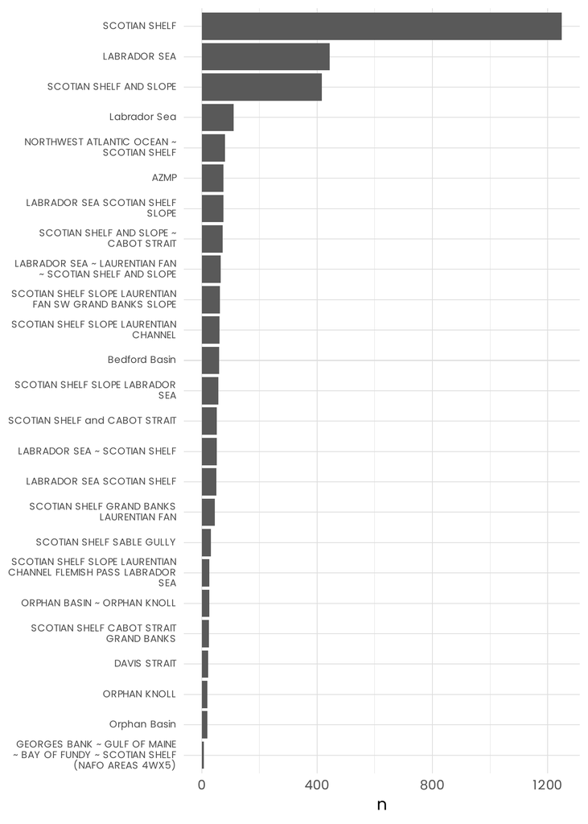

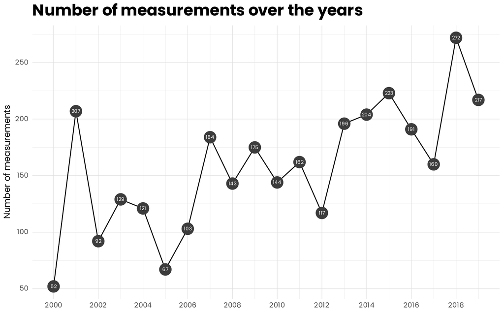

## Bioregions

Observations were classified into bioregions based on the following criteria (where `position` is `south` if `latitude < 48`):

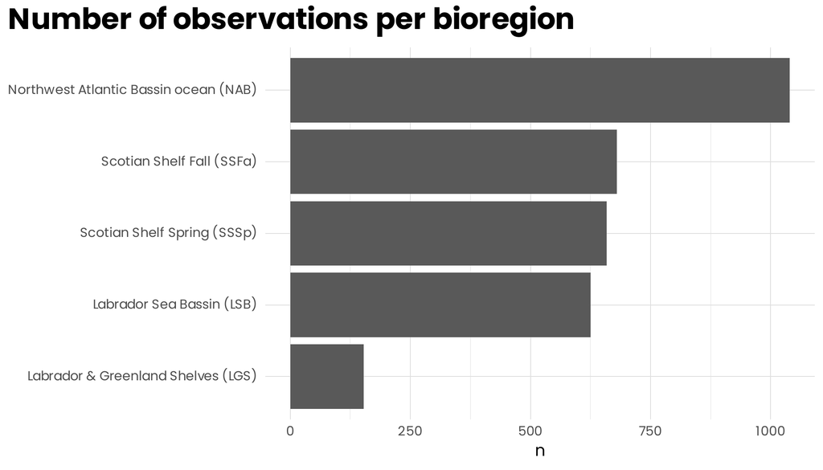

```r
bathymetry > -300 & position == "North" ~ "Labrador & Greenland Shelves (LGS)"
bathymetry <= -300 & position == "North" ~ "Labrador Sea Bassin (LSB)"
bathymetry >= -300 & position == "South" & yday <= 180 ~ "Scotian Shelf Spring (SSSp)"
bathymetry >= -300 & position == "South" & yday > 180 ~ "Scotian Shelf Fall (SSFa)"
bathymetry < -300 & position == "South"~ "Northwest Atlantic Bassin ocean (NAB)"
```

## Geographical map

This is not the final map, but it gives a first spatial overview of the data.

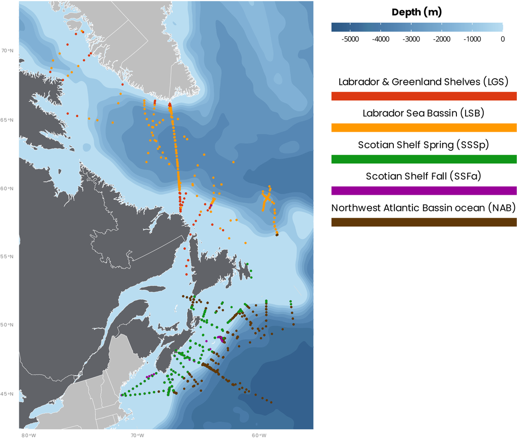

## HPLC

- I also noticed there are a lot of `0` in the HPLC data.
  - Should we consider `0` values as real `0` or missing values?
- There are `hplchla` and `hplcchla` variables in the data. What is the difference?

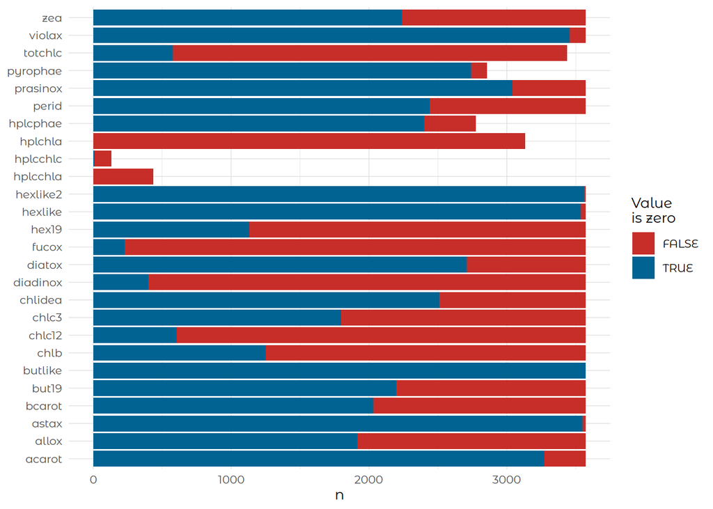

## Absorption

- Here is how I named absorption data:
  - `anap` is the data contained in files with `detritus` in their name.
  - `ap` is the data contained in files with `particulate` in their name.
  - `aphy` is the data contained in files with `phytoplankton` in their name.
- Is the absorption data ready to go (i.e. no further processing required)?

A quick look at one sample (378972) seems to indicate no…

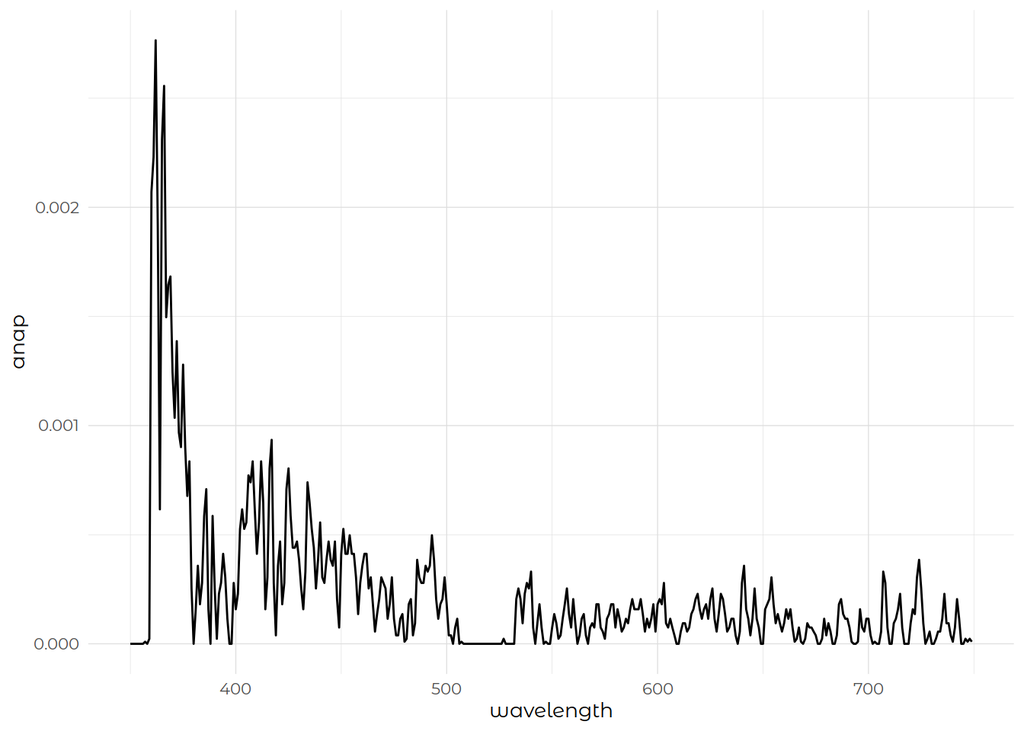

- How should we use the quality flags?
- I think we should only keep the 2671 spectra where all the three flags are at 1.

| qc_flag_410_smaller_than_440 | qc_flag_443_to_490 | qc_flag_chl_a_to_443_550_670 | n |
| --- | --- | --- | --- |
| 0 | 0 | 0 | 113 |
| 1 | 1 | 1 | 2671 |
| 1 | 1 | 2 | 45 |
| 1 | 2 | 1 | 60 |
| 1 | 2 | 2 | 2 |
| 4 | 1 | 1 | 290 |
| 4 | 1 | 2 | 9 |
| 4 | 2 | 1 | 21 |

Overview pf `aphy` per bioregion. We can see that there are some negative values at low wavelengths (see `Northwest Atlantic Bassin ocean (NAB)`).

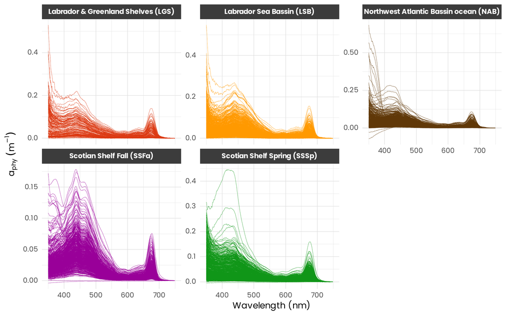

## TODOS

- Calculate `snap`.
- Calculate `aphy_specific`.